# Weeks 14&15 A Two-way ANOVA

Dinkar Sharma, Lazaros Gonidis

19/09/2022

## Introduction

In this exercise, we will look at two-way between-participants ANOVA. Before the exercise itself, we will learn how to compute simple main effects. There are various ways of computing simple effects in R, but the method outlined below is very quick and simple. However, keep in mind that this technique only works for completely between-participants designs.

`library(haven) ### used to load SPSS .sav files, read_sav()`  
`library(tidyverse) ### for general purpose functions`  
`library(rstatix) ### used for our ANOVA, anova_test()` `library(emmeans) ### used for emmeans() to explore simple main effects`  
`library(ggpubr) ### used for graphs such as gghistogram()`  
`library(gmodels) ### used for fit.contrast() to create contrasts`

Let’s start by opening the dataset **2-WayBetween-SubjectsAnova.sav**. This is data from a sample of judges: the experimenters described a crime to the judges, and then showed them a picture of the supposed defendant. The judges then decided what sentence they would hand down to this defendant. There were two IVs: the first IV (**sexdiff**) was whether the defendant was the same sex as the judge (1 = same sex, 2 = opposite sex). The second IV (**attract**) was whether the defendant in the picture was attractive (1), unattractive (2), or no picture was shown (3). The DV is the sentence in years. (We have manipulated these data for the purposes of this exercise, so don’t be too judgemental of the judges when you see the results!)

We will start by running the overall analysis (also known as an ‘omnibus analysis’) as we have done in previous weeks. We will open the datafile, assign it to a dataframe, declare our factor levels and labels, and acquire means. Note that we will be using the function `factor` and not `as.factor` as it allows us to quickly specify levels and labels.

```r
library(haven) ### used to load SPSS .sav files, read_sav()
library(tidyverse) ### for general purpose functions
library(rstatix) ### used for our ANOVA, anova_test()
library(ggpubr) ### used for graphs such as gghistogram()

df <- read_sav("2-WayBetween-SubjectsAnova.sav")


df$sexdiff <-factor(df$sexdiff,
                       levels=c(1,2),
                       labels=c("same", "opposite"))


df$attract <-factor(df$attract,
                       levels=c(1,2,3),
                       labels=c("attractive", "unattractive", "no picture"))
summary(df)
```

```
##      sexdiff           attract      sentence
##  same    :30   attractive  :20   Min.   : 2.00
##  opposite:30   unattractive:20   1st Qu.: 8.75
##                no picture  :20   Median :11.00
##                                  Mean   :10.25
##                                  3rd Qu.:13.00
##                                  Max.   :16.00
```

```r
## marginal means per sexdiff and attact
df %>%
  group_by(sexdiff, attract) %>%
  get_summary_stats(sentence, type = "mean_sd")
```

```
## # A tibble: 6 x 6
##   sexdiff  attract      variable     n  mean    sd
##   <fct>    <fct>        <chr>    <dbl> <dbl> <dbl>
## 1 same     attractive   sentence    10   7.7  1.83
## 2 same     unattractive sentence    10  13.2  2.3
## 3 same     no picture   sentence    10  12.9  1.66
## 4 opposite attractive   sentence    10   3.9  1.29
## 5 opposite unattractive sentence    10  12.3  2.06
## 6 opposite no picture   sentence    10  11.5  1.65
```

```r
## marginal means for the main effect of sexdiff
df %>%
  group_by(sexdiff) %>%
  get_summary_stats(sentence, type = "mean_sd")
```

```
## # A tibble: 2 x 5
##   sexdiff  variable     n  mean    sd
##   <fct>    <chr>    <dbl> <dbl> <dbl>
## 1 same     sentence    30 11.3   3.18
## 2 opposite sentence    30  9.23  4.18
```

```r
## marginal means for the main effect of attract
df %>%
  group_by(attract) %>%
  get_summary_stats(sentence, type = "mean_sd")
```

```
## # A tibble: 3 x 5
##   attract      variable     n  mean    sd
##   <fct>        <chr>    <dbl> <dbl> <dbl>
## 1 attractive   sentence    20   5.8  2.48
## 2 unattractive sentence    20  12.8  2.17
## 3 no picture   sentence    20  12.2  1.76
```

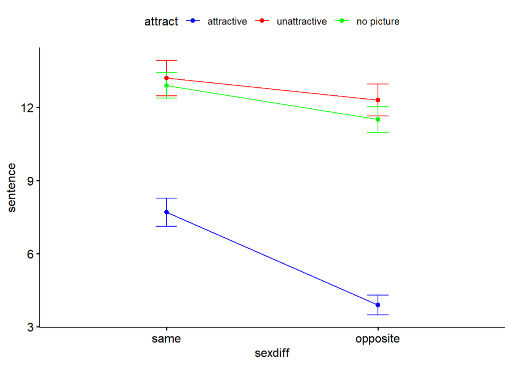

```r
## ggline requires ggpubr
## in your lecture slides we also used ggplot2
## you can try using ggplot2 for more practice

ggline(df, x = "sexdiff", y = "sentence",
       color = "attract",  ###instead of color you could use line etc
       add = "mean_se",
       palette = c("blue", "red", "green"))
```

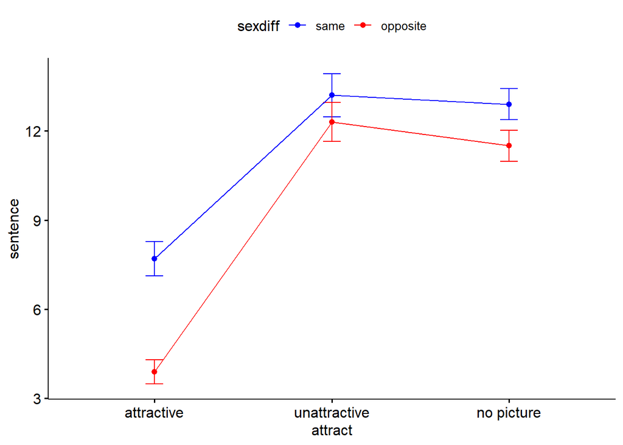

```r
## the same data plotted with attraction on x-axis
## this might be easier for comparisons
## generally we advise placing the factor with the most levels
## on the x-axis
ggline(df, x = "attract", y = "sentence",
       color = "sexdiff",  ###instead of color you could use line etc
       add = "mean_se",
       palette = c("blue", "red"))
```

Before moving on, try to interpret the two graphs in terms of simple main effects. The subsequent analysis will provide you the statistical tools to confirm these simple main effects.

We will now carry out the two-way ANOVA. At this point it is important to stress that `aov()` and `anova_test()` have different functionality in terms of the type of sums of squares. The `aov()` function is using type I as default and should only be used for balanced data, whereas `anova_test()` can be used with any type of sums of squares. Below you can see the analysis with both these functions, and since our data are balanced (same sample size across all conditions) they both yield the same results. For more information on types of sums of squares please follow this link: https://www.r-bloggers.com/2011/03/anova-%e2%80%93-type-iiiiii-ss-explained/

```r
result.aov <- aov(sentence ~ sexdiff*attract, data=df)
summary(result.aov)
```

```
##                 Df Sum Sq Mean Sq F value  Pr(>F)
## sexdiff          1     62    62.0    18.6 6.9e-05 ***
## attract          2    597   298.6    89.5 < 2e-16 ***
## sexdiff:attract  2     24    12.0     3.6   0.034 *
## Residuals       54    180     3.3
## ---
## Signif. codes:  0 '***' 0.001 '**' 0.01 '*' 0.05 '.' 0.1 ' ' 1
```

```r
#### these two approaches give the same results here

df %>%
  anova_test(sentence ~ sexdiff*attract, type = 3)
```

```
## ANOVA Table (type III tests)
##
##            Effect DFn DFd    F        p p<.05   ges
## 1         sexdiff   1  54 18.6 6.91e-05     * 0.256
## 2         attract   2  54 89.5 7.15e-18     * 0.768
## 3 sexdiff:attract   2  54  3.6 3.40e-02     * 0.118
```

```r
model <-lm(sentence ~ sexdiff*attract, data=df,
          contrasts=list(sexdiff=contr.sum, attracte=contr.sum),
          type = 3)
car::Anova(model, type=3)
```

```
## Anova Table (Type III tests)
##
## Response: sentence
##                 Sum Sq Df F value  Pr(>F)
## (Intercept)        673  1   201.7 < 2e-16 ***
## sexdiff             72  1    21.6 2.2e-05 ***
## attract            597  2    89.5 < 2e-16 ***
## sexdiff:attract     24  2     3.6   0.034 *
## Residuals          180 54
## ---
## Signif. codes:  0 '***' 0.001 '**' 0.01 '*' 0.05 '.' 0.1 ' ' 1
```

In your future work you **should only use aov() when your data are balanced** in any other case you should use either `anova_test()` or `car::Anova()`. For peace of mind you can use the two latter ones in all cases.

If you look at the means for each condition (either the table or the graphs), you will see that there is a bigger difference between same- and other-sex defendants in the attractive condition than there is in the unattractive and no picture conditions. This is the interaction: an interaction between two IVs simply means that the effect on one IV on the DV varies, depending on which condition of the other IV you are looking at. But the interaction does not tell you which of these attract effects are significant; to fully describe the interaction, you need to do simple main effects.

```r
## As per your lecture slides we have to use lm() and define the model
model1 <- lm(sentence ~ sexdiff*attract, data=df)

## simple main effect of attract within each level of sexdiff
## as our design is between subjects we need to
## use the error from the overall model1

df %>%
  group_by(sexdiff) %>%
  anova_test(sentence ~ attract, error = model1, detailed = TRUE)
```

```
## # A tibble: 2 x 10
##   sexdiff  Effect    SSn   SSd   DFn   DFd     F        p `p<.05`   ges
## * <fct>    <chr>   <dbl> <dbl> <dbl> <dbl> <dbl>    <dbl> <chr>   <dbl>
## 1 same     attract  191.  180.     2    54  28.7 3.27e- 9 *       0.515
## 2 opposite attract  430.  180.     2    54  64.4 4.96e-15 *       0.705
```

```r
## simple main effect of sexdiff within each level of attract
df %>%
  group_by(attract) %>%
  anova_test(sentence ~ sexdiff, error = model1, detailed = TRUE)
```

```
## # A tibble: 3 x 10
##   attract      Effect    SSn   SSd   DFn   DFd     F         p `p<.05`   ges
## * <fct>        <chr>   <dbl> <dbl> <dbl> <dbl> <dbl>     <dbl> <chr>   <dbl>
## 1 attractive   sexdiff 72.2   180.     1    54 21.6  0.0000216 "*"     0.286
## 2 unattractive sexdiff  4.05  180.     1    54  1.21 0.275     ""      0.022
## 3 no picture   sexdiff  9.8   180.     1    54  2.94 0.092     ""      0.052
```

```r
## As above we declare our model
library(emmeans)
model1 <- lm(sentence ~ sexdiff*attract, data=df)

## we then use the emmeans package
## specifically the functions joint_test() for simple main effects
## within the levels of the second factor

simple <- joint_tests(model1, by ="sexdiff")
simple
```

```
## sexdiff = same:
##  model term df1 df2 F.ratio p.value
##  attract      2  54  28.700  <.0001
##
## sexdiff = opposite:
##  model term df1 df2 F.ratio p.value
##  attract      2  54  64.400  <.0001
```

```r
## we then follow this up with emmeans()
## in order to get pairwise comparisons
## and marginal means

## we declare our model, and the order or variables
simple_sexdiff <- emmeans(model1,  ~ attract | sexdiff)

## we call pairs() to run the pairwise comparisons
simple_sexdiff %>%
  pairs()
```

```
## sexdiff = same:
##  contrast                  estimate    SE df t.ratio p.value
##  attractive - unattractive     -5.5 0.817 54  -6.730  <.0001
##  attractive - no picture       -5.2 0.817 54  -6.370  <.0001
##  unattractive - no picture      0.3 0.817 54   0.370  0.9280
##
## sexdiff = opposite:
##  contrast                  estimate    SE df t.ratio p.value
##  attractive - unattractive     -8.4 0.817 54 -10.290  <.0001
##  attractive - no picture       -7.6 0.817 54  -9.310  <.0001
##  unattractive - no picture      0.8 0.817 54   0.980  0.5930
##
## P value adjustment: tukey method for comparing a family of 3 estimates
```

```r
## print() displays the marginal means
print(simple_sexdiff)
```

```
## sexdiff = same:
##  attract      emmean    SE df lower.CL upper.CL
##  attractive      7.7 0.578 54     6.54     8.86
##  unattractive   13.2 0.578 54    12.04    14.36
##  no picture     12.9 0.578 54    11.74    14.06
##
## sexdiff = opposite:
##  attract      emmean    SE df lower.CL upper.CL
##  attractive      3.9 0.578 54     2.74     5.06
##  unattractive   12.3 0.578 54    11.14    13.46
##  no picture     11.5 0.578 54    10.34    12.66
##
## Confidence level used: 0.95
```

```r
### repeat the same process for the second variable
simple_attract <- emmeans(model1,  ~ sexdiff | attract)

simple_attract %>%
  pairs()
```

```
## attract = attractive:
##  contrast        estimate    SE df t.ratio p.value
##  same - opposite      3.8 0.817 54   4.650  <.0001
##
## attract = unattractive:
##  contrast        estimate    SE df t.ratio p.value
##  same - opposite      0.9 0.817 54   1.100  0.2754
##
## attract = no picture:
##  contrast        estimate    SE df t.ratio p.value
##  same - opposite      1.4 0.817 54   1.710  0.0922
```

```r
print(simple_attract)
```

```
## attract = attractive:
##  sexdiff  emmean    SE df lower.CL upper.CL
##  same        7.7 0.578 54     6.54     8.86
##  opposite    3.9 0.578 54     2.74     5.06
##
## attract = unattractive:
##  sexdiff  emmean    SE df lower.CL upper.CL
##  same       13.2 0.578 54    12.04    14.36
##  opposite   12.3 0.578 54    11.14    13.46
##
## attract = no picture:
##  sexdiff  emmean    SE df lower.CL upper.CL
##  same       12.9 0.578 54    11.74    14.06
##  opposite   11.5 0.578 54    10.34    12.66
##
## Confidence level used: 0.95
```

At this point it is worth contrasting these statistical outputs to the visual information provided by the two graphs above. Were you correct in your predictions of possible significant simple main effects?

## Task 1.

Open the **gss.sav** file in the folder-ALL WEEKS - R files for computing exercises. Here we are going to carry out an analysis of variance to see if the level of income that the respondent receives is related to their gender and the level of education that they reached. When you run the ANOVA, ask the computer to give you a table of descriptive statistics as well.

The data for this week are taken from a general social survey conducted in the US examining various demographic factors as well as measures of life satisfaction. This exercise illustrates a two-way, between subjects analysis of variance. The first factor is SEX. If the respondent is male , SEX = 1; if female, SEX = 2. The second factor is DEGREE. DEGREE = 0 if the respondent did not finish high school, DEGREE = 1 if the respondents education ended upon completing high school, DEGREE = 2 if the respondent completed a junior college degree, DEGREE = 3 if the respondent completed an undergraduate degree, and DEGREE = 4 if the respondent completed a postgraduate degree.

The dependent variable for this exercise is INCOME: the total family income reported by the respondent (in US dollars). Values for income range from 1 to 17 with 1 = under 1,000 and 17 = 50,000 or more. Some other points on the income continuum include: 4 = 4,000 - 4,999, 8 = 8,000 - 8,999, 12 = 17,500 - 19,999, 16 = 35,000 - 49,999.

Q1) How many respondents are in the study? What is the Grand Mean Income?  
Q2) How many respondents are male? What is the marginal mean income for male respondents?  
Q3) How many respondents highest reported degree is an Undergraduate degree? What is the marginal mean income for this level of the degree factor?  
Q4) How many female respondents highest educational attainment was the completion of high school? What is the cell mean for Income in this condition?  
Q5) Report the F-value, Degrees of freedom, significance level and the MS error for the SEX, DEGREE and SEX x DEGREE effects.  
Q6) How would you interpret any significant main effects?  
Q7) Is the interaction effect significant? If so, what interpretation would you offer for it?

## Task 2: Simple Effects Analysis.

Continue with a simple effect analysis and answer the questions below

Q1) Report the F-value, Degrees of freedom, and significance for each tested simple effect.

Q2) Give a verbal interpretation of each tested simple effect. What does each one mean?

Q3) Given the pattern of simple effects, what interpretation would you offer for the significant two-wayinteraction in the ANOVA.

## Task 1: Solution

```r
library(haven) ### used to load SPSS .sav files, read_sav()
library(tidyverse) ### for general purpose functions
library(rstatix) ### used for our ANOVA, anova_test()
library(ggpubr) ### used for graphs such as gghistogram()
library(car)


gss <- read_sav("gss.sav")


gss$sex <-factor(gss$sex,
                       levels=c(1,2),
                       labels=c("male", "female"))


gss$degree <-factor(gss$degree,
                       levels=c(0, 1, 2, 3, 4),
                       labels=c("nohighschool","highschool", "junior college", "bachelor", "graduate"))

summary(gss)
```

```
##        id            race          age         sex         marital
##  Min.   :   1   Min.   :1.0   Min.   :18   male  :598   Min.   :1.00
##  1st Qu.: 369   1st Qu.:1.0   1st Qu.:29   female:875   1st Qu.:1.00
##  Median : 737   Median :1.0   Median :40                Median :1.00
##  Mean   : 737   Mean   :1.1   Mean   :44                Mean   :2.18
##  3rd Qu.:1105   3rd Qu.:1.0   3rd Qu.:58                3rd Qu.:3.00
##  Max.   :1473   Max.   :2.0   Max.   :89                Max.   :5.00
##                 NA's   :52    NA's   :6
##      satjob        hapmar         life         postlife        educ
##  Min.   :1.0   Min.   :1     Min.   :1.00   Min.   :1.0   Min.   : 0.0
##  1st Qu.:1.0   1st Qu.:1     1st Qu.:1.00   1st Qu.:1.0   1st Qu.:11.0
##  Median :2.0   Median :1     Median :2.00   Median :1.0   Median :12.0
##  Mean   :1.8   Mean   :1     Mean   :1.58   Mean   :1.2   Mean   :12.4
##  3rd Qu.:2.0   3rd Qu.:2     3rd Qu.:2.00   3rd Qu.:1.0   3rd Qu.:14.0
##  Max.   :4.0   Max.   :3     Max.   :3.00   Max.   :2.0   Max.   :20.0
##  NA's   :265   NA's   :648   NA's   :12     NA's   :121   NA's   :3
##             degree        paeduc        maeduc         speduc        income
##  nohighschool  :400   Min.   : 0    Min.   : 0.0   Min.   : 0    Min.   : 1.0
##  highschool    :764   1st Qu.: 8    1st Qu.: 8.0   1st Qu.:12    1st Qu.: 9.0
##  junior college: 54   Median :11    Median :12.0   Median :12    Median :13.0
##  bachelor      :175   Mean   :10    Mean   :10.3   Mean   :12    Mean   :11.6
##  graduate      : 77   3rd Qu.:12    3rd Qu.:12.0   3rd Qu.:14    3rd Qu.:15.0
##  NA's          :  3   Max.   :20    Max.   :20.0   Max.   :20    Max.   :17.0
##                       NA's   :406   NA's   :233    NA's   :650   NA's   :131
##      health         hompop          agewed          sibs          paeindex
##  Min.   :1.00   Min.   : 1.00   Min.   :12.0   Min.   : 0.00   Min.   :1
##  1st Qu.:1.00   1st Qu.: 2.00   1st Qu.:19.0   1st Qu.: 2.00   1st Qu.:1
##  Median :2.00   Median : 2.00   Median :21.0   Median : 3.00   Median :1
##  Mean   :1.97   Mean   : 2.71   Mean   :21.9   Mean   : 4.14   Mean   :1
##  3rd Qu.:2.00   3rd Qu.: 4.00   3rd Qu.:24.0   3rd Qu.: 6.00   3rd Qu.:2
##  Max.   :4.00   Max.   :10.00   Max.   :50.0   Max.   :24.00   Max.   :2
##  NA's   :12                     NA's   :297    NA's   :8       NA's   :433
##     educindx       maeindex
##  Min.   :1.00   Min.   :1.0
##  1st Qu.:1.00   1st Qu.:1.0
##  Median :2.00   Median :2.0
##  Mean   :1.72   Mean   :1.5
##  3rd Qu.:2.00   3rd Qu.:2.0
##  Max.   :2.00   Max.   :2.0
##  NA's   :6      NA's   :266
```

```r
## marginal means per sexdiff and attact
gss %>%
  group_by(sex, degree) %>%
  get_summary_stats(income, type = "mean_sd")
```

```
## # A tibble: 11 x 6
##    sex    degree         variable     n  mean    sd
##    <fct>  <fct>          <chr>    <dbl> <dbl> <dbl>
##  1 male   nohighschool   income     150 10.1   4.23
##  2 male   highschool     income     272 12.1   4.09
##  3 male   junior college income      15 11.7   4.66
##  4 male   bachelor       income      79 14.5   2.76
##  5 male   graduate       income      49 14.8   2.97
##  6 male   <NA>           income       1 14    NA
##  7 female nohighschool   income     199  8.06  4.30
##  8 female highschool     income     425 11.9   4.12
##  9 female junior college income      38 12.2   3.22
## 10 female bachelor       income      88 13.5   3.60
## 11 female graduate       income      26 14.5   2.14
```

```r
## marginal means per sex
gss %>%
  group_by(sex) %>%
  get_summary_stats(income, type = "mean_sd")
```

```
## # A tibble: 2 x 5
##   sex    variable     n  mean    sd
##   <fct>  <chr>    <dbl> <dbl> <dbl>
## 1 male   income     566  12.1  4.20
## 2 female income     776  11.2  4.46
```

```r
## marginal means per degree
gss %>%
  group_by(degree) %>%
  get_summary_stats(income, type = "mean_sd")
```

```
## # A tibble: 6 x 5
##   degree         variable     n  mean    sd
##   <fct>          <chr>    <dbl> <dbl> <dbl>
## 1 nohighschool   income     349  8.93  4.38
## 2 highschool     income     697 12.0   4.11
## 3 junior college income      53 12.1   3.64
## 4 bachelor       income     167 14.0   3.26
## 5 graduate       income      75 14.7   2.70
## 6 <NA>           income       1 14    NA
```

```r
## ggline requires ggpubr
## in your lecture slides we also used ggplot2
## you can try using ggplot2 for more practice




### Carrying out the 2-way ANOVA
### We will use both aov() and anova_test() to highlight the different results
### this is because we have unbalanced data
### for your work it is your responsibility to check whether your data are balanced


task1.aov <- aov(income ~ sex*degree, data=gss)
summary.aov(task1.aov, type = 3)
```

```
##               Df Sum Sq Mean Sq F value  Pr(>F)
## sex            1    267     267   16.93 4.1e-05 ***
## degree         4   4151    1038   65.80 < 2e-16 ***
## sex:degree     4    220      55    3.49  0.0076 **
## Residuals   1331  20993      16
## ---
## Signif. codes:  0 '***' 0.001 '**' 0.01 '*' 0.05 '.' 0.1 ' ' 1
## 132 observations deleted due to missingness
```

```r
gss %>%
  anova_test(income ~ sex*degree, type = 3)
```

```
## ANOVA Table (type III tests)
##
##       Effect DFn  DFd     F        p p<.05   ges
## 1        sex   1 1331  2.77 9.60e-02       0.002
## 2     degree   4 1331 61.31 1.39e-47     * 0.156
## 3 sex:degree   4 1331  3.49 8.00e-03     * 0.010
```

```r
### We also using car::Anova to demonstrate the similarity of results with anova_test()

model1 <-lm(income ~ sex*degree, data=gss,
          contrasts=list(sex=contr.sum, degree=contr.sum), type = 3)
car::Anova(model1, type=3)
```

```
## Anova Table (Type III tests)
##
## Response: income
##             Sum Sq   Df F value Pr(>F)
## (Intercept)  78545    1 4979.87 <2e-16 ***
## sex             44    1    2.77 0.0962 .
## degree        3868    4   61.31 <2e-16 ***
## sex:degree     220    4    3.49 0.0076 **
## Residuals    20993 1331
## ---
## Signif. codes:  0 '***' 0.001 '**' 0.01 '*' 0.05 '.' 0.1 ' ' 1
```

1. How many respondents are in the study? What is the Grand Mean Income?

**N=1473, Grand Mean Income = 11.59, you can get that from summary(ggs) or do a separate mean(gss$income)**

Q2) How many respondents are male? What is the marginal mean income for male respondents?

Q3) How many respondents highest reported degree is an Undergraduate degree? What is the marginal mean income for this level of the degree factor?

**N = 167, M = 14.0**

Q4) How many female respondents highest educational attainment was the completion of high school? What is the cell mean for Income in this condition?

**N = 425, M = 11.9**

Q5) Report the F-value, Degrees of freedom, significance level and the MS error for the SEX, DEGREE and SEX x DEGREE effects.

The following is the word document answer

**Main effect of sex: F(1,1331) = 2.77, p = .096**  
**Main effect of degree: F(4,1331) = 61.31, p < .001**  
**Interaction between sex and degree: F(4,1331) = 3.49, p = .008**  
**You can refer back to One-Way Anova exercise to see how we calculated the MSE**

Q6) How would you interpret any significant main effects?

**The main effect of Degree reflects a general increase in income from low to high education attainment levels. Follow-up analyses are needed to specify more precisely the nature of these differences.**

Q7) Is the interaction effect significant? If so, what interpretation would you offer for it?

**The interaction effect is significant. It appears to be due to a general tendency for males’ income levels to exceed those of females for all educational attainment levels except Junior College, where the pattern is in the opposite direction. Again, follow up analyses are needed to be sure about the precise pattern.**

## Task 2: Solution

```r
## As per your lecture slides we have to use lm() and define the model

library(tidyverse)

model2 <- lm(income ~ sex*degree, data=gss)

## simple main effect of degree within each level of sex
## as our design is between subjects we need to
## use the error from the overall model2

gss %>%
  group_by(degree) %>%
  anova_test(income ~ sex, error = model2, detailed = TRUE)
```

```
## Error: Problem with `mutate()` column `data`.
## i `data = map(.data$data, .f, ...)`.
## x contrasts can be applied only to factors with 2 or more levels
```

```r
gss %>%
  group_by(sex) %>%
  anova_test(income ~ degree, error = model2, detailed = TRUE)
```

```
## # A tibble: 2 x 10
##   sex    Effect   SSn    SSd   DFn   DFd     F        p `p<.05`   ges
## * <fct>  <chr>  <dbl>  <dbl> <dbl> <dbl> <dbl>    <dbl> <chr>   <dbl>
## 1 male   degree 1414. 20993.     4  1331  22.4 6.19e-18 *       0.063
## 2 female degree 2957. 20993.     4  1331  46.9 6.73e-37 *       0.123
```

The above analysis returned an error for the first simple main effects analysis, this is due to missing data in our variables. When R removed the missing data rows we ended up with a single level factor. A way around this is to remove missing values before we deal with the problematic analysis. Keep in mind that you should only do this if you are faced with an error message like the one above, and you should only do it for the problematic analysis and not for all your variables. It should also be noted that this is not an efficient method as it may result in huge loss of data. There are various techniques for dealing with missing values, such as imputation, but they fall outside the scope of today’s lesson.

```r
## As per your lecture slides we have to use lm() and define the model

library(tidyverse)

model2 <- lm(income ~ sex*degree, data=gss)

## use na.omit()  to remove missing values
gss.1 <- na.omit(gss)

gss.1 %>%
  group_by(degree) %>%
  anova_test(income ~ sex, error = model2, detailed = TRUE)
```

```
## # A tibble: 5 x 10
##   degree         Effect    SSn    SSd   DFn   DFd     F     p `p<.05`        ges
## * <fct>          <chr>   <dbl>  <dbl> <dbl> <dbl> <dbl> <dbl> <chr>        <dbl>
## 1 nohighschool   sex    35.0   20993.     1  1331 2.22  0.136 ""         2   e-3
## 2 highschool     sex     0.016 20993.     1  1331 0.001 0.975 ""         7.55e-7
## 3 junior college sex    11.7   20993.     1  1331 0.744 0.388 ""         5.59e-4
## 4 bachelor       sex     8.21  20993.     1  1331 0.521 0.471 ""         3.91e-4
## 5 graduate       sex     2.02  20993.     1  1331 0.128 0.721 ""         9.61e-5
```

```r
## As per your lecture slides we have to use lm() and define the model

model2 <- lm(income ~ sex*degree, data=gss)


## we then use the emmeans package
## specifically the functions joint_test() for simple main effects
## within the levels of the second factor

simple <- joint_tests(model2, by ="sex")
simple
```

```
## sex = male:
##  model term df1  df2 F.ratio p.value
##  degree       4 1331  22.400  <.0001
##
## sex = female:
##  model term df1  df2 F.ratio p.value
##  degree       4 1331  46.900  <.0001
```

```r
## we then follow this up with emmeans()
## in order to get pairwise comparisons
## and marginal means

## we declare our model, and the order or variables
simple_sex <- emmeans(model2,  ~ degree | sex)

## we call pairs() to run the pairwise comparisons
simple_sex %>%
  pairs()
```

```
## sex = male:
##  contrast                      estimate    SE   df t.ratio p.value
##  nohighschool - highschool        -2.00 0.404 1331  -4.960  <.0001
##  nohighschool - junior college    -1.58 1.075 1331  -1.470  0.5830
##  nohighschool - bachelor          -4.41 0.552 1331  -7.980  <.0001
##  nohighschool - graduate          -4.69 0.653 1331  -7.180  <.0001
##  highschool - junior college       0.42 1.053 1331   0.400  0.9950
##  highschool - bachelor            -2.41 0.508 1331  -4.740  <.0001
##  highschool - graduate            -2.69 0.616 1331  -4.360  <.0001
##  junior college - bachelor        -2.83 1.119 1331  -2.530  0.0850
##  junior college - graduate        -3.11 1.172 1331  -2.650  0.0620
##  bachelor - graduate              -0.28 0.722 1331  -0.390  0.9950
##
## sex = female:
##  contrast                      estimate    SE   df t.ratio p.value
##  nohighschool - highschool        -3.86 0.341 1331 -11.310  <.0001
##  nohighschool - junior college    -4.17 0.703 1331  -5.930  <.0001
##  nohighschool - bachelor          -5.41 0.508 1331 -10.640  <.0001
##  nohighschool - graduate          -6.43 0.828 1331  -7.770  <.0001
##  highschool - junior college      -0.31 0.672 1331  -0.470  0.9900
##  highschool - bachelor            -1.55 0.465 1331  -3.340  0.0080
##  highschool - graduate            -2.58 0.802 1331  -3.210  0.0120
##  junior college - bachelor        -1.24 0.771 1331  -1.610  0.4920
##  junior college - graduate        -2.26 1.011 1331  -2.240  0.1660
##  bachelor - graduate              -1.02 0.886 1331  -1.150  0.7780
##
## P value adjustment: tukey method for comparing a family of 5 estimates
```

```r
## print() displays the marginal means
print(simple_sex)
```

```
## sex = male:
##  degree         emmean    SE   df lower.CL upper.CL
##  nohighschool    10.09 0.324 1331     9.45    10.72
##  highschool      12.09 0.241 1331    11.62    12.56
##  junior college  11.67 1.025 1331     9.66    13.68
##  bachelor        14.49 0.447 1331    13.62    15.37
##  graduate        14.78 0.567 1331    13.66    15.89
##
## sex = female:
##  degree         emmean    SE   df lower.CL upper.CL
##  nohighschool     8.07 0.282 1331     7.51     8.62
##  highschool      11.92 0.193 1331    11.54    12.30
##  junior college  12.24 0.644 1331    10.97    13.50
##  bachelor        13.48 0.423 1331    12.65    14.31
##  graduate        14.50 0.779 1331    12.97    16.03
##
## Confidence level used: 0.95
```

```r
simple <- joint_tests(model2, by ="degree")
simple
```

```
## degree = nohighschool:
##  model term df1  df2 F.ratio p.value
##  sex          1 1331  22.160  <.0001
##
## degree = highschool:
##  model term df1  df2 F.ratio p.value
##  sex          1 1331   0.290  0.5910
##
## degree = junior college:
##  model term df1  df2 F.ratio p.value
##  sex          1 1331   0.220  0.6380
##
## degree = bachelor:
##  model term df1  df2 F.ratio p.value
##  sex          1 1331   2.730  0.0990
##
## degree = graduate:
##  model term df1  df2 F.ratio p.value
##  sex          1 1331   0.080  0.7750
```

```r
## we then follow this up with emmeans()
## in order to get pairwise comparisons
## and marginal means


## WE REPEAT THE SAME PROECESS FOR THE SECOND FACTOR

## we declare our model, and the order or variables
simple_degree <- emmeans(model2,  ~ sex | degree)

## we call pairs() to run the pairwise comparisons
simple_degree %>%
  pairs()
```

```
## degree = nohighschool:
##  contrast      estimate    SE   df t.ratio p.value
##  male - female    2.021 0.429 1331   4.710  <.0001
##
## degree = highschool:
##  contrast      estimate    SE   df t.ratio p.value
##  male - female    0.166 0.308 1331   0.540  0.5910
##
## degree = junior college:
##  contrast      estimate    SE   df t.ratio p.value
##  male - female   -0.570 1.211 1331  -0.470  0.6380
##
## degree = bachelor:
##  contrast      estimate    SE   df t.ratio p.value
##  male - female    1.016 0.616 1331   1.650  0.0990
##
## degree = graduate:
##  contrast      estimate    SE   df t.ratio p.value
##  male - female    0.276 0.964 1331   0.290  0.7750
```

```r
## print() displays the marginal means
print(simple_degree)
```

```
## degree = nohighschool:
##  sex    emmean    SE   df lower.CL upper.CL
##  male    10.09 0.324 1331     9.45    10.72
##  female   8.07 0.282 1331     7.51     8.62
##
## degree = highschool:
##  sex    emmean    SE   df lower.CL upper.CL
##  male    12.09 0.241 1331    11.62    12.56
##  female  11.92 0.193 1331    11.54    12.30
##
## degree = junior college:
##  sex    emmean    SE   df lower.CL upper.CL
##  male    11.67 1.025 1331     9.66    13.68
##  female  12.24 0.644 1331    10.97    13.50
##
## degree = bachelor:
##  sex    emmean    SE   df lower.CL upper.CL
##  male    14.49 0.447 1331    13.62    15.37
##  female  13.48 0.423 1331    12.65    14.31
##
## degree = graduate:
##  sex    emmean    SE   df lower.CL upper.CL
##  male    14.78 0.567 1331    13.66    15.89
##  female  14.50 0.779 1331    12.97    16.03
##
## Confidence level used: 0.95
```

Q1) Report the F-value, Degrees of freedom, significance level for each tested simple effect.

**Significant simple main effect of degree in the male condition: F(4,1331) = 22.4, p < .001**

**Significant simple main effect of degree in the female condition: F(4,1331) = 46.9, p < .001**

**Significant Simple main effect of sex in the nohighschool condition: F(1,1331) = 22.16, p < .001**

**The other simple main effects of sex were not significant, all F’s < 2.74, and p’s > .09**

Q2) Give a verbal interpretation of each tested simple effect. What does each one mean?  
**SEX WITHIN LT High School: Is there a difference in income levels between men and women who did not complete high school?**

**SEX WITHIN High School: Is there a difference in income levels between men and women whose highest level of educational attainment was completing high school?**  
**SEX WITHIN Junior College: Is there a difference in income levels between men and women whose highest level of educational attainment was completing junior college?**

**SEX WITHIN Bachelors: Is there a difference in income levels between men and women whose highest level of educational attainment was completing a bachelor’s degree?**

**SEX WITHIN Graduate: Is there a difference in income levels between men and women whose highest level of educational attainment was beyond the bachelor’s degree?**

**DEGREE WITHIN Male: Are there any differences in the mean income levels of men at the study’s five different levels of educational attainment?**

**DEGREE WITHIN Female: Are there any differences in the mean income levels of women at the study’s five different levels of educational attainment?**

Q3) Given the pattern of simple effects, what interpretation would you offer for the significant two-way interaction in the ANOVA.

**In general the income levels of men do not differ from those of women at most levels of educational attainment. There is however, one exception to this general pattern, which accounts for the interaction effect. Specifically, men’s income level is significantly higher than that of women amongst respondents who did not finish high school.**